# Milestone 4

Katherine Enright

10/11/2019

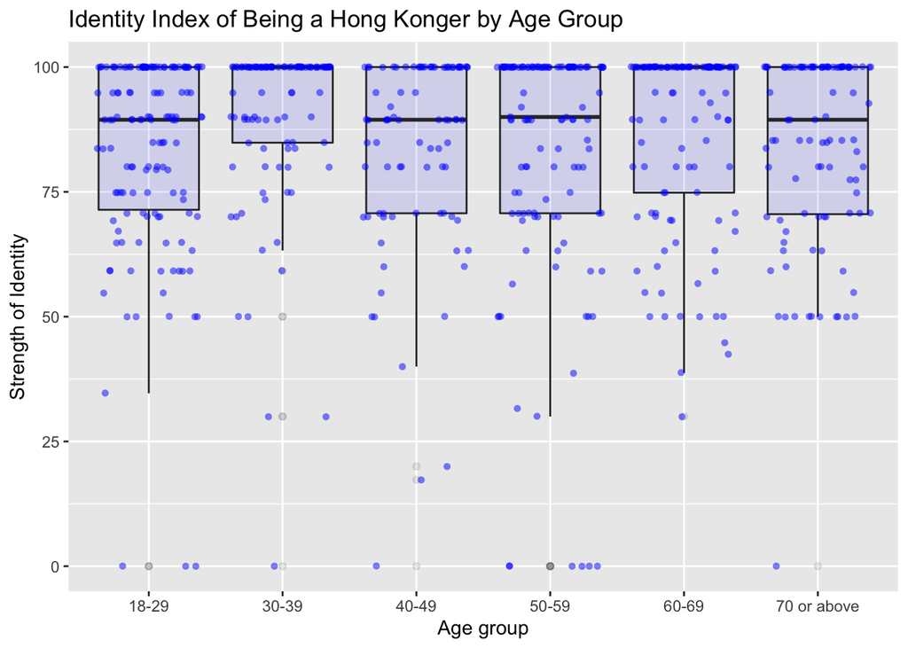

One common assumption, especially with regards to the current protests, is that the younger generation in Hong Kong have a stronger unique Hong Kong identity as opposed to Chinese identity. The data displayed here in this graph questions that assumption, and shows a fairly consistent high percentage of identification with Hong Kong identity across age groups. The next step of my analysis will be to compare this “Identity Index of Being a Hong Konger” (Q002I) with the “Identity index of being a Chinese citizen” (Q003I).

I chose to plot the results of question Q002I in this box plot as it is an index that combines the values for the two questions on HK identity— “please use a scale of 0-10 to rate your strength of identity as a Hongkonger”(Q002A) and “Please use a scale of 0-10 to rate your importance as a Hongkonger” (Q002B).

Source: Survey of Nationality and Identity in Hong Kong, Public Opinion Programme, The University of Hong Kong